# Self-Organized Criticality

#### Random Input

```
T=10
```

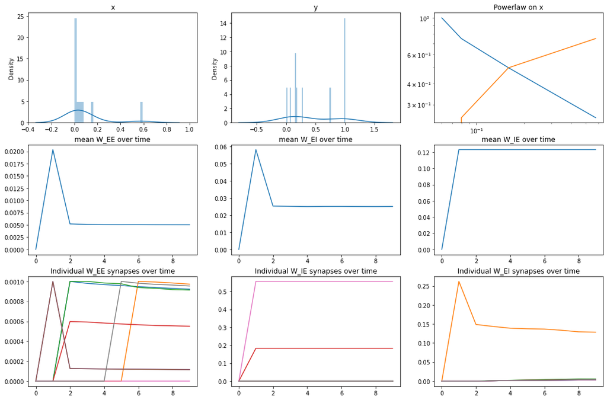

```
================================
T=100
```

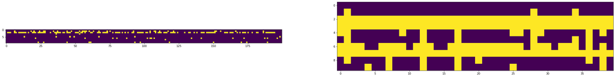

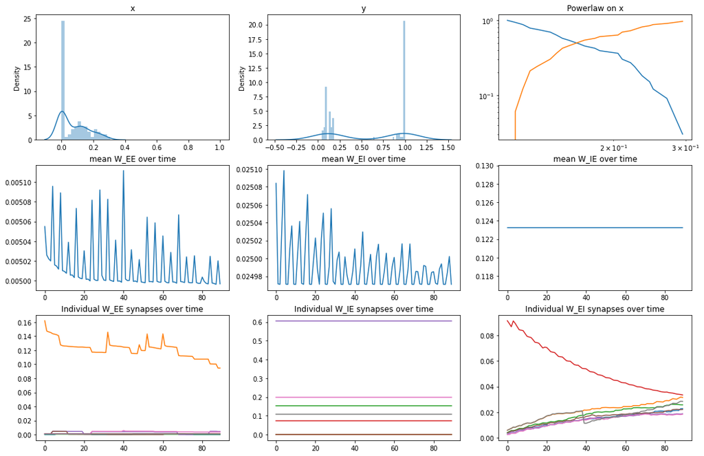

```
================================
T=1000
```

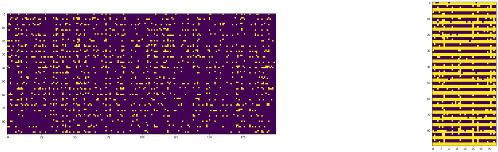

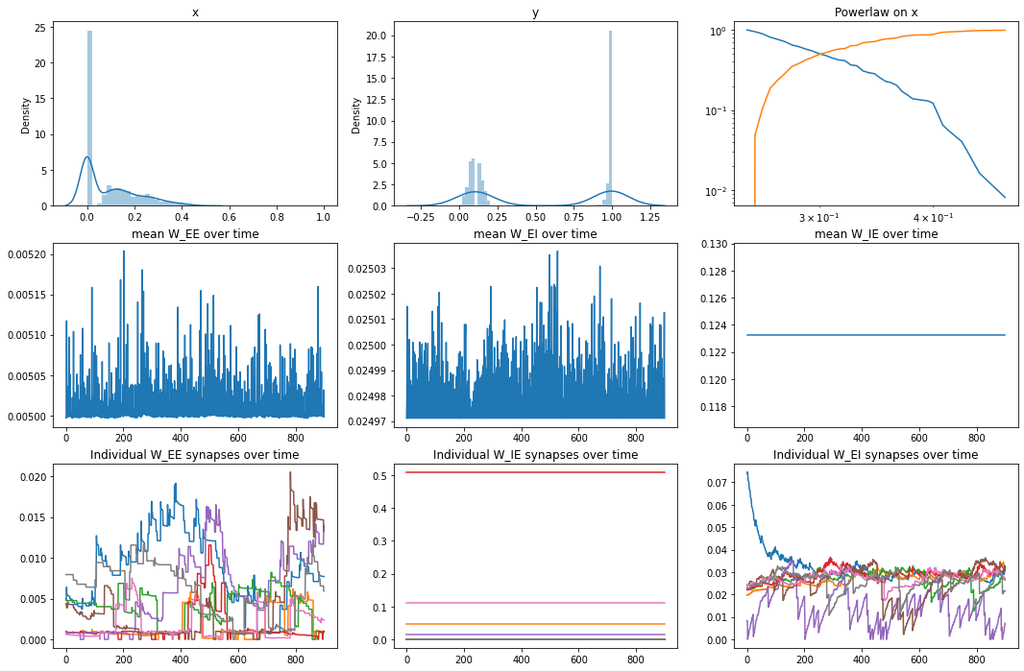

```
================================
T=1500
```

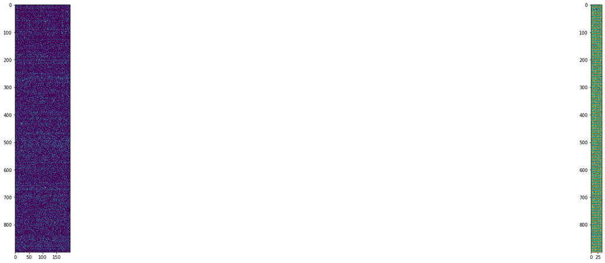

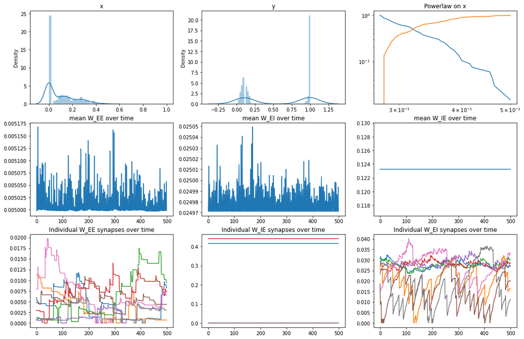

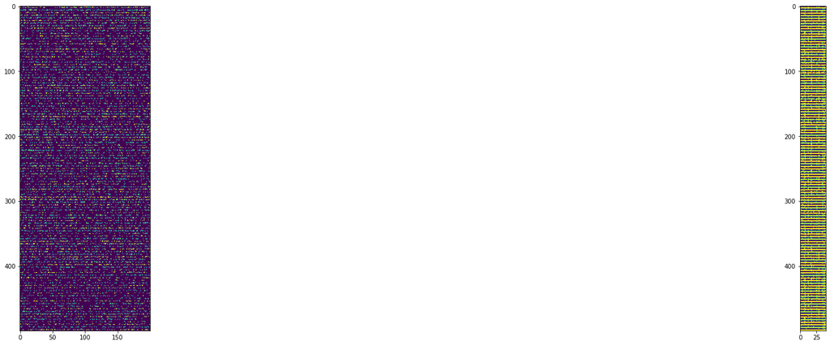

```python
def random_input(t):
    return tf.zeros((t, 200)) + int(t > 1000) * tf.random.uniform((t, 200), 0, 1)

logger = experiment(
    control_params=dict(
        N_E = 200,
        N_I = 40,
    ),
    Ts=[10, 100, 1000, 1500],
    input_fn=random_input)
```

```
T=10
```

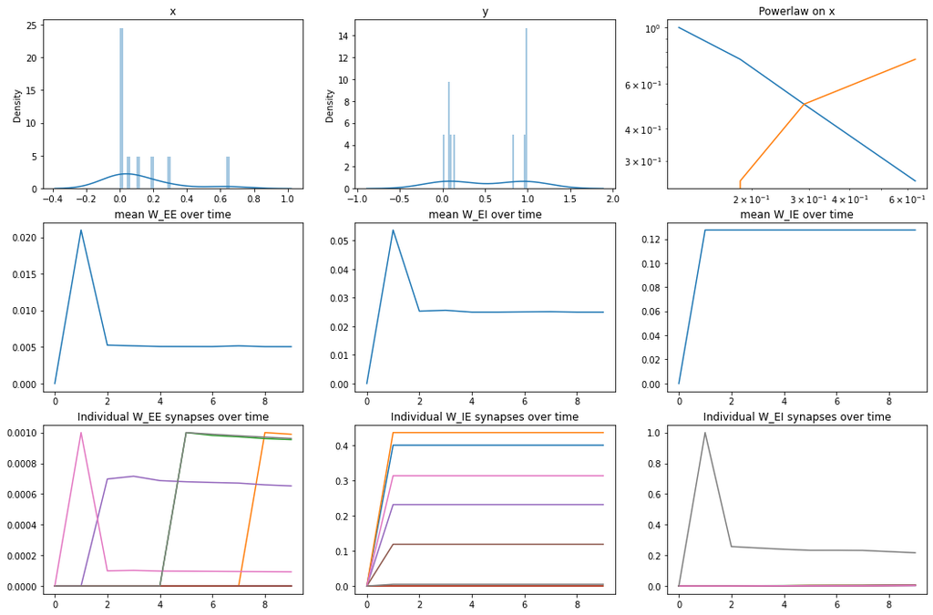

```
================================
T=100
```

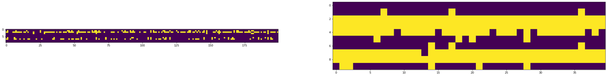

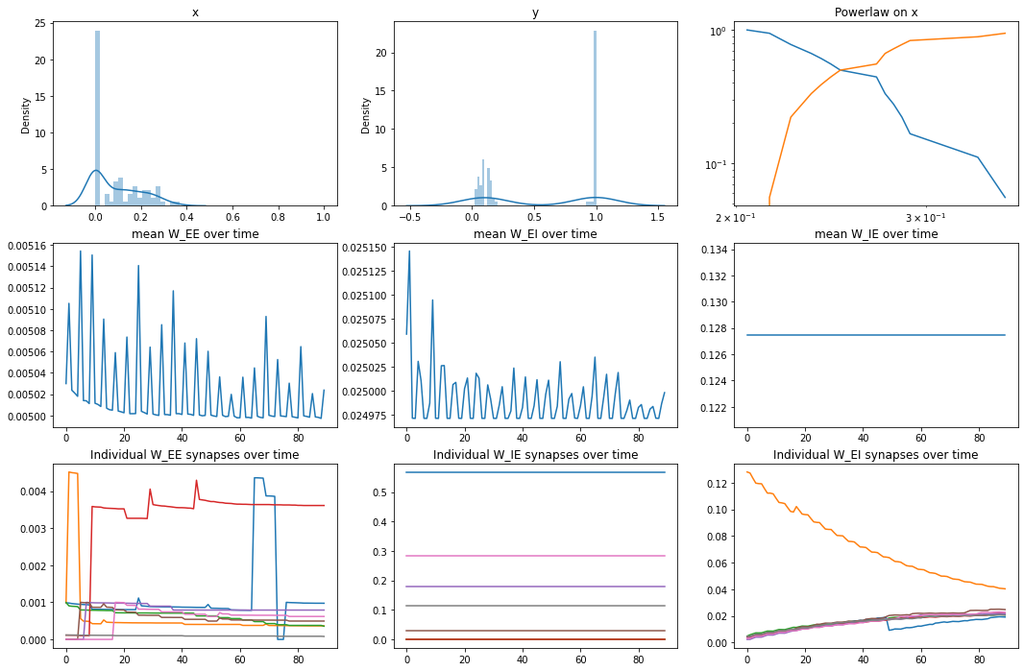

```
================================
T=1000
```

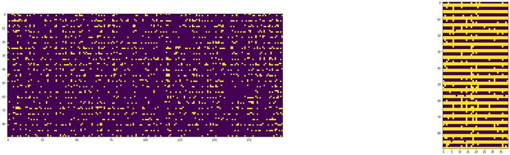

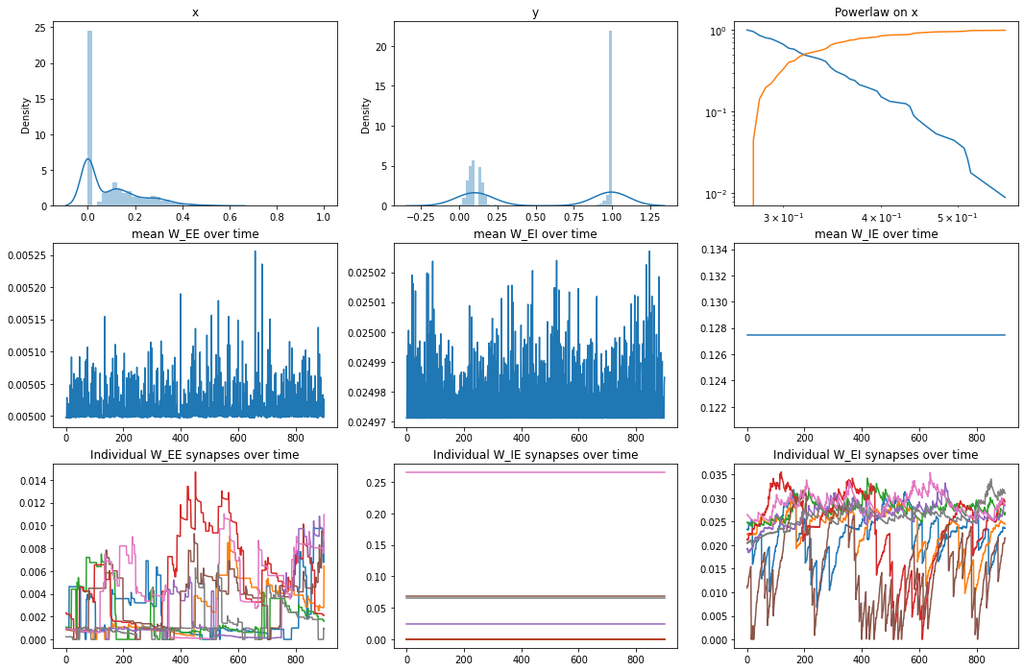

```
================================
T=1500
```

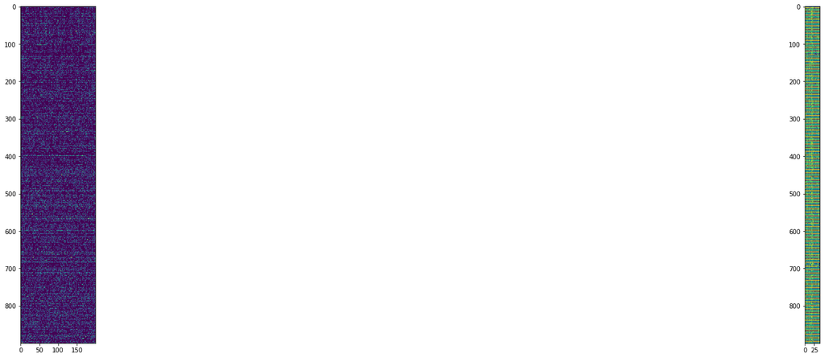

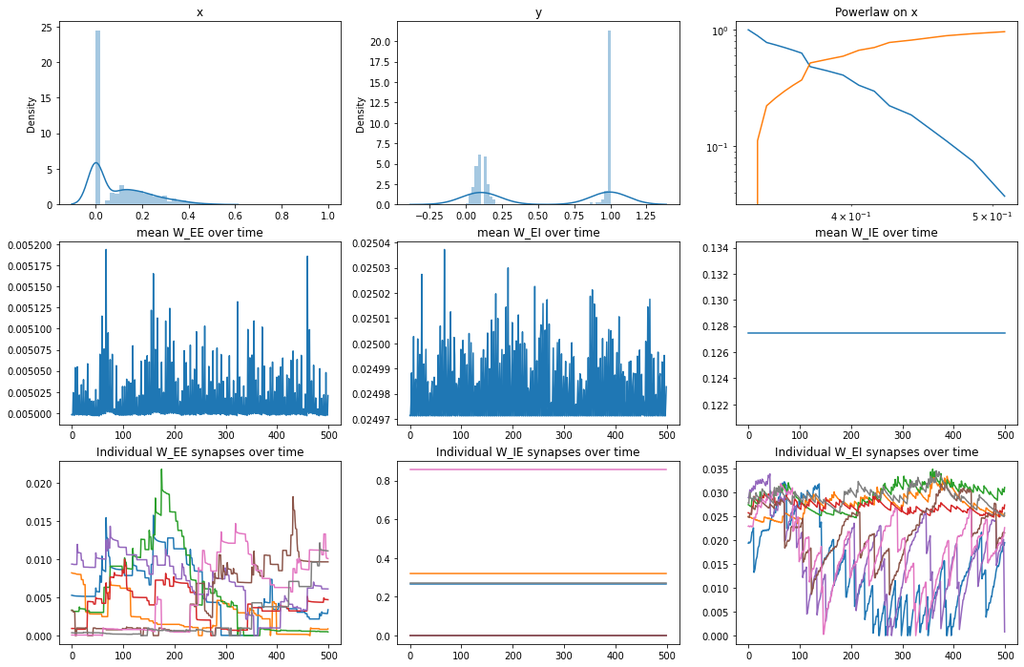

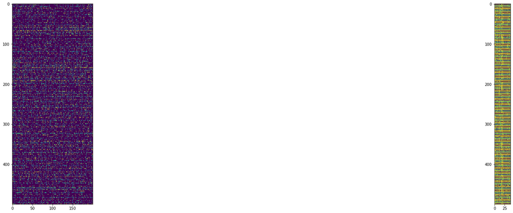

```python
def normal_input(t):
    return tf.zeros((t, 200)) + int(t > 1000) * tf.random.normal((t, 200),
                                                                 mean=0, stddev=1)

logger = experiment(
    control_params=dict(
        N_E = 200,
        N_I = 40,
    ),
    Ts=[10, 100, 1000, 1500],
    input_fn=normal_input)
```

#### Structured Input

```
T=10
```

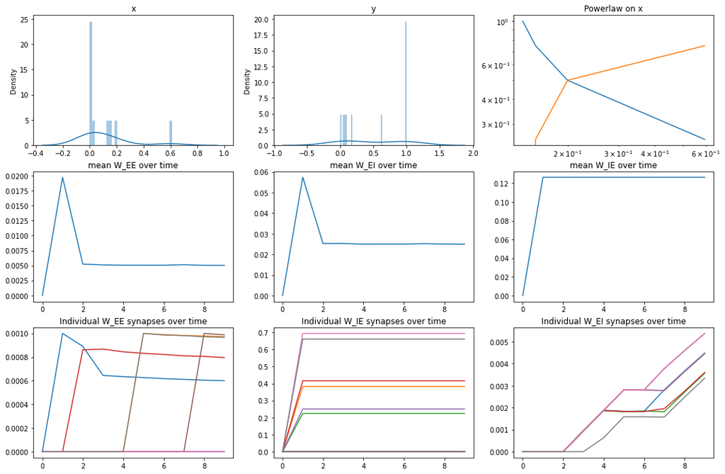

```
================================
T=100
```

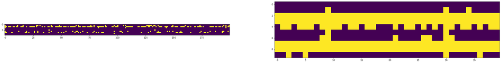

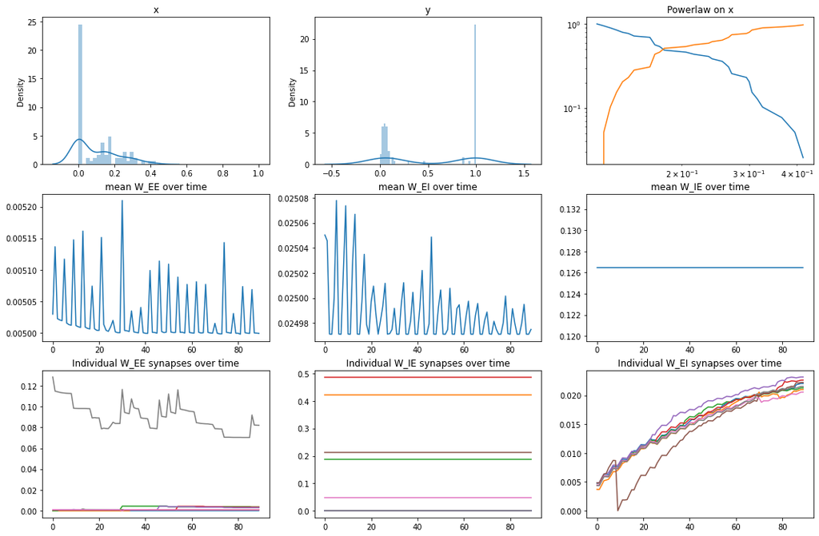

```
================================
T=1000
```

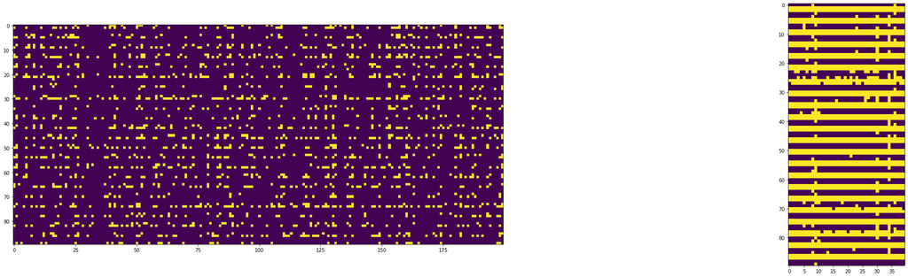

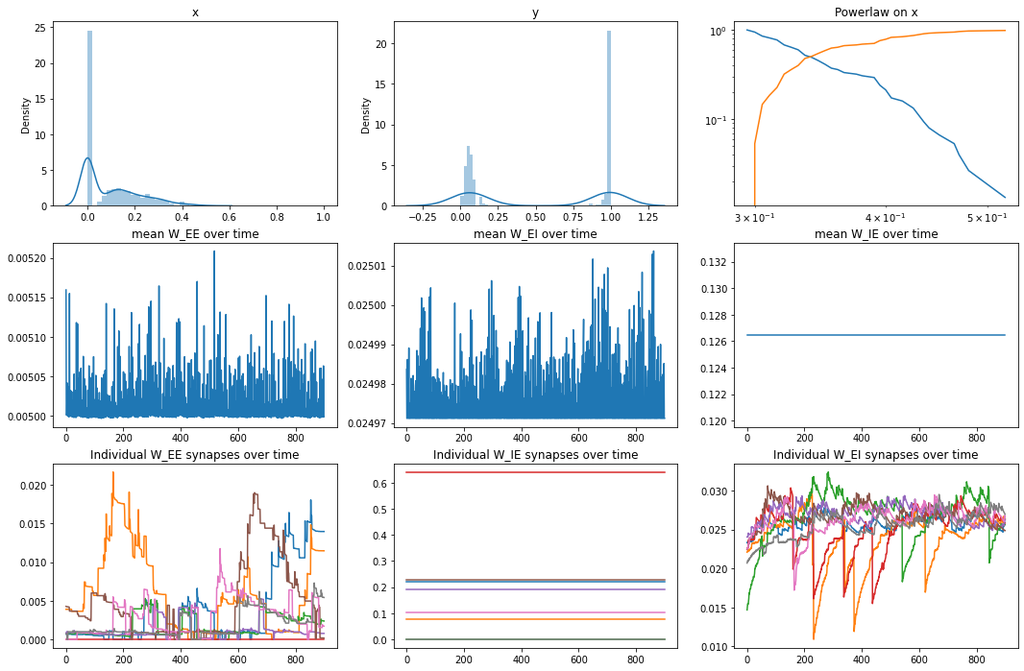

```
================================
T=1500
```

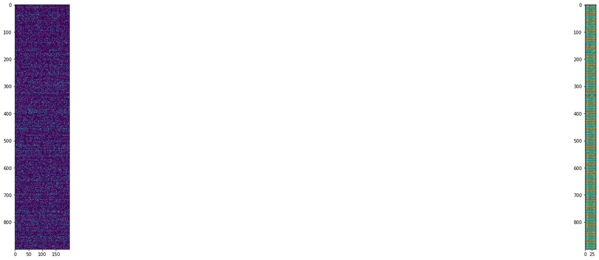

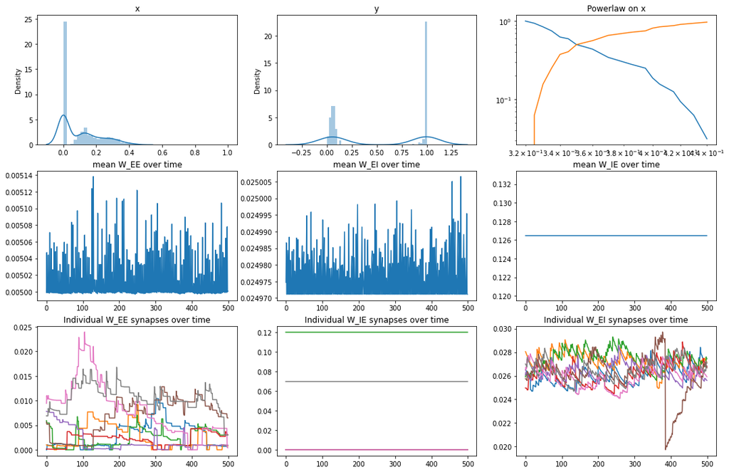

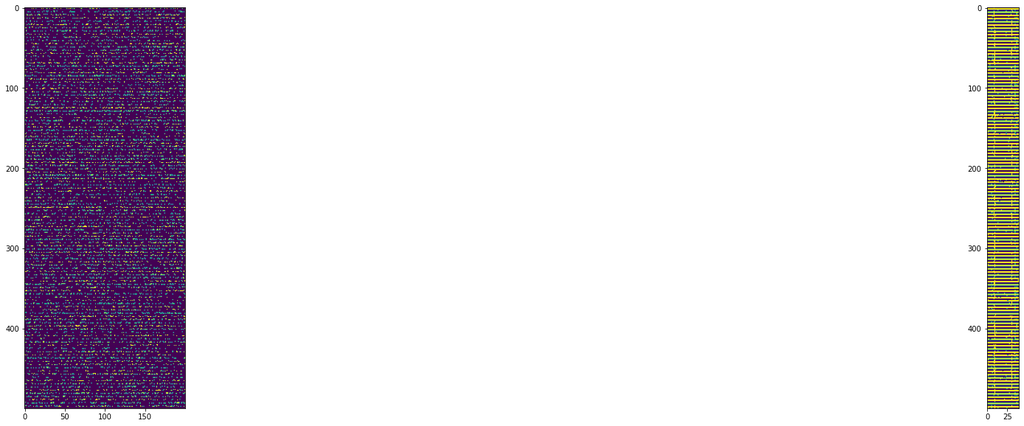

```python
RND = np.random.random(size=(200, 4))
def structured_input(t):
    if t < 1000:
        return tf.zeros((t, 200))
    else:
        return RND[:, int(t)//2 % 4]

logger = experiment(
    control_params=dict(
        N_E = 200,
        N_I = 40,
    ),
    Ts=[10, 100, 1000, 1500],
    input_fn=structured_input)
```

## Notes

#### Is learning maximized when internal dynamics are already at the edge of criticality?

**Background** Intelligence is a scarse resource and must be utilized effectively to maximize growth. Intrinsically motivated learning can only select a subset of information from the environment to send through the bottleneck of interaction. However the human's subjective measure of information is not equal to information theory's negative log likelihood. Instead the brain acquires maximum information about its environment from stimuli that are neither overly boring nor excessively surprising. Rather, it is critical information which varies in-between either extreme that maximally attracts attention. For example, my intrinsic motivation to learn gravitates toward material somewhere in-between the high-school and post-docoral levels.

(Del Papa et al. 2017) confirmed structured input *temporarily* breaks down critical dynamics. However, power laws reliably return after a period of readaptation.

**Observations**

- nroam input looked more chaotic than structured input which looked more chaotic than uniform and more than no input
- I did not observe criticality break down under synthetic structured input
- need to test character sequence inputs

**Conclusion** I cannot make any conclusion of certainty from the above experiments. Criticality will continue to be a focus of study.